# R Notebook

Introduction

Today we will be analyzing the titanic dataset. We will use various ML models, different cross-validation(CV) tools, and feature selection to see which models give us the best prediction. This is a kaggle competition.

Link to competition: https://www.kaggle.com/c/titanic

| PassengerId | Survived | Pclass | Name | Sex | Age | SibSp | Parch | Ticket | Fare | Cabin | Embarked | Type.of.data |
| --- | --- | --- | --- | --- | --- | --- | --- | --- | --- | --- | --- | --- |
| 1 | 0 | 3 | Braund, Mr. Owen Harris | male | 22 | 1 | 0 | A/5 21171 | 7.2500 | NA | S | Train.data |
| 2 | 1 | 1 | Cumings, Mrs. John Bradley (Florence Briggs Thayer) | female | 38 | 1 | 0 | PC 17599 | 71.2833 | C85 | C | Train.data |
| 3 | 1 | 3 | Heikkinen, Miss. Laina | female | 26 | 0 | 0 | STON/O2. 3101282 | 7.9250 | NA | S | Train.data |
| 4 | 1 | 1 | Futrelle, Mrs. Jacques Heath (Lily May Peel) | female | 35 | 1 | 0 | 113803 | 53.1000 | C123 | S | Train.data |
| 5 | 0 | 3 | Allen, Mr. William Henry | male | 35 | 0 | 0 | 373450 | 8.0500 | NA | S | Train.data |
| 6 | 0 | 3 | Moran, Mr. James | male | NA | 0 | 0 | 330877 | 8.4583 | NA | Q | Train.data |

Data preprocessing

Our first step is to modify the variables to their respective categories: numeric, categorical, and then we will assess the missing values

Now we will assess missing values in our dataset

```
             [,1]
PassengerId     0
Survived      418
Pclass          0
Name            0
Sex             0
Age           263
SibSp           0
Parch           0
Ticket          0
Fare            1
Cabin        1014
Embarked        2
Type.of.data    0
```

We will try to perform *EDA* and see if we can get any insights on how to impute these missing values

EDA

EDA Analysis 1: Age

*Histogram of age*

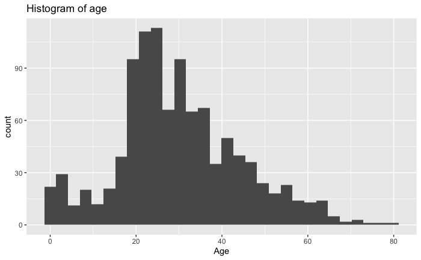

We see that age is roughly normally distributed

We will now see how *Age* correlates with the categogical varibales

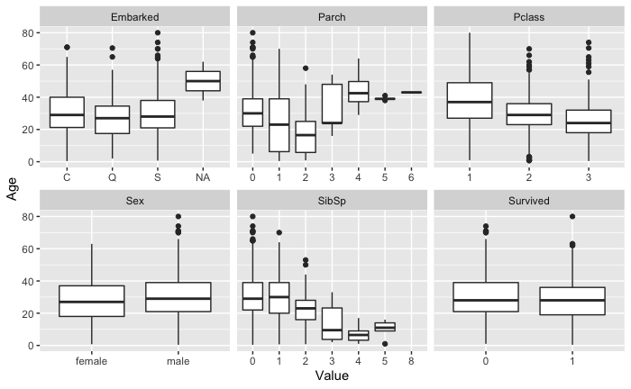

From the looks of this, there seems to be some pattern with Age and Pclass, so we will take a further analysis into this. We are not dealing with *Parch and SibSp* just yet since they both seem to be correlated with each other

We will explore more with *Age and Pclass*

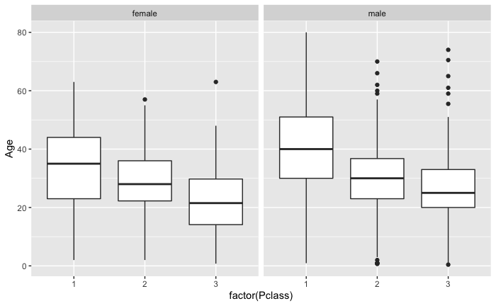

From the looks of it, we can impute *Medain* values for the age based on *Sex and Pclass*

*Updated histogram for Age*

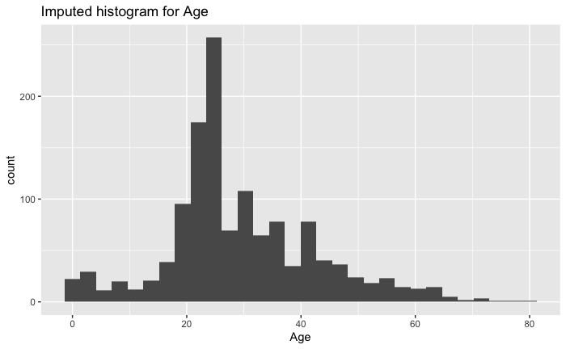

EDA Analysis 2: Pclass

We will first see the realtionship between *Pclass and Embarked*

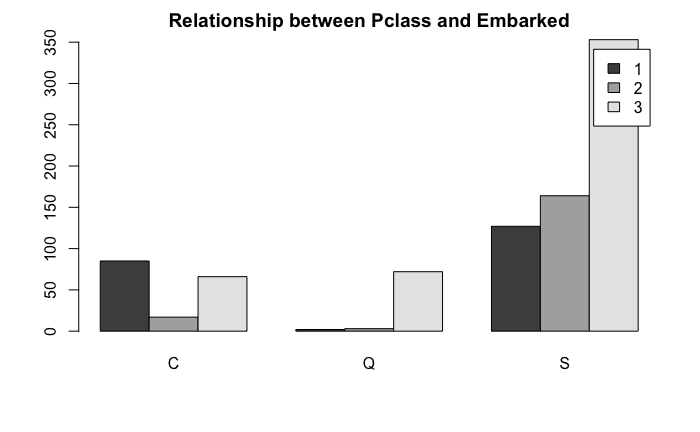

From the analysis, we can create a new factor named *Pclass.Embarked.relationship* (look at code)

We will take *SibSp and Parch* and add them up and call it *Family.size.numeric*

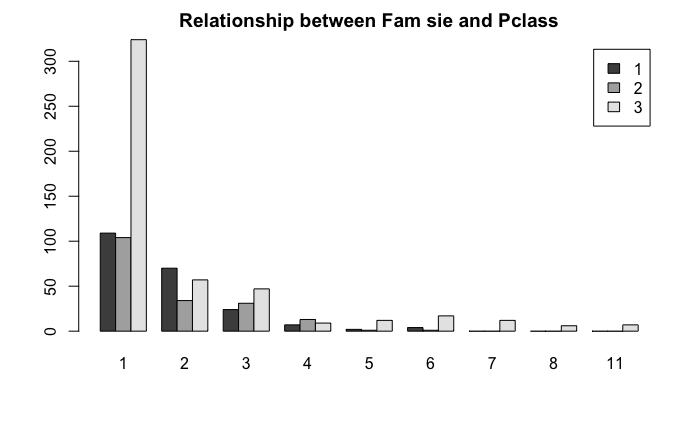

EDA Analysis 3: Fare

```r
# Only 1 value has a missing value for Fare
length(which(is.na(combined.data$Fare)))
```

```
[1] 1
```

We will impute the missing values of *Fare* with the median value

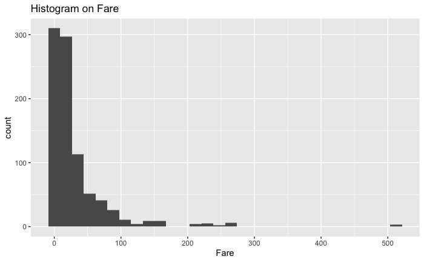

We will see the realtionship between *Fare* and other categorical varibales

```
attributes are not identical across measure variables;
they will be dropped
```

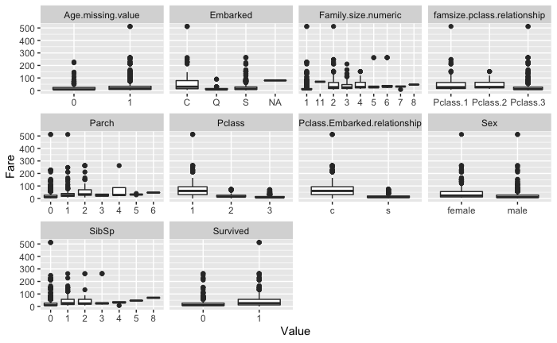

We will try to categorize *fare*, it may be useful in our model. We will call this varibale *Fare.factor*

EDA Analysis 4: Name

We will extract the tittle in people’s name so we can use them in our model. We will call this new factor *Name.abr*. From the barplot, we see that *Mr* are the ones that died the most

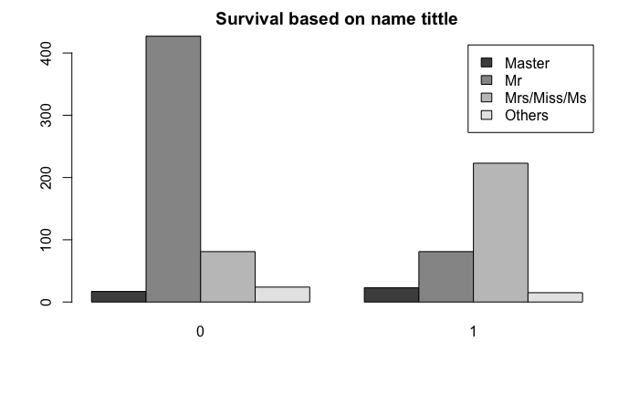

We will extract the last names of each passenger and call it *Last.name*

EDA Analysis 5: Family Size

We will create a varibale called *Is alone* for only 1 passesnger

EDA Analysis 6: Cabin

Since there are alot of missing values, we will just impute those missing values with the factor *unknown*

We will remove name out of our analysis since we don’t need it anymore

Feature Selection

We will use *information gain* as our source of varibale importance. This chart tells us what varibales will be very useful in our model. From the plot, we see that Ticket has the highest information, so we will still comtinue our analysis to see how we can use *Ticket and Last.name*. Since these 2 varibales have alot of factors, we need another way to categorize them

```
Provided data is not a pure data.frame but from class tbl_df, hence it will be converted.
```

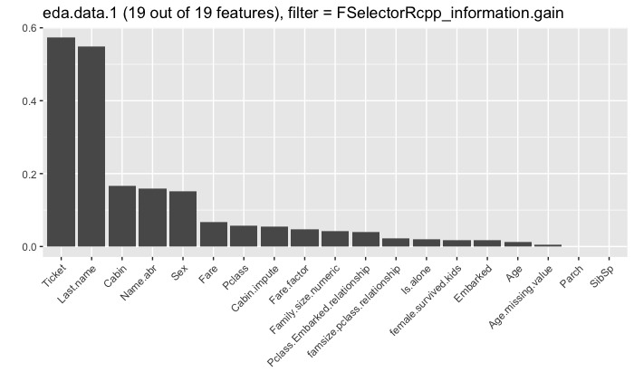

Modelling

We will split the data into train and test

```
[1] 891
[1] 418
```

We will create a *xgboost model* and fine-tune and parameters to get a *pseduo-survival* score

```r
getParamSet("classif.xgboost")
```

|  | Type | len | Def | Constr | Req | Tunable | Trafo |
| --- | --- | --- | --- | --- | --- | --- | --- |
| booster | discrete | - | gbtree | gbtree,gblinear,dart | - | TRUE | - |
| watchlist | untyped | - |  | - | - | FALSE | - |
| eta | numeric | - | 0.3 | 0 to 1 | - | TRUE | - |
| gamma | numeric | - | 0 | 0 to Inf | - | TRUE | - |
| max_depth | integer | - | 6 | 0 to Inf | - | TRUE | - |
| min_child_weight | numeric | - | 1 | 0 to Inf | - | TRUE | - |
| subsample | numeric | - | 1 | 0 to 1 | - | TRUE | - |
| colsample_bytree | numeric | - | 1 | 0 to 1 | - | TRUE | - |
| colsample_bylevel | numeric | - | 1 | 0 to 1 | - | TRUE | - |
| num_parallel_tree | integer | - | 1 | 1 to Inf | - | TRUE | - |

[output cut: 34 more lines]

We will *fine-tune our XGBOOST* model *manually* since that is much easier

```
Provided data is not a pure data.frame but from class tbl_df, hence it will be converted.Resampling: cross-validation
Measures:             mmce      acc
[Resample] iter 1:    0.2178771 0.7821229
[Resample] iter 2:    0.2191011 0.7808989
[Resample] iter 3:    0.2247191 0.7752809
[Resample] iter 4:    0.1864407 0.8135593
[Resample] iter 5:    0.1787709 0.8212291


Aggregated Result: mmce.test.mean=0.2053818,acc.test.mean=0.7946182


Provided data for prediction is not a pure data.frame but from class tbl_df, hence it will be converted.
```

Our *psudo survival* has an accuracy of 0.79. We will treat this as a new factor and incorporate it into our analysis (dataframe)

We will now see if there is a relationship between *Last name and our presudo-survived*. We will group the values based on last name and if the mean of them is greater than 0.5, we wil call it 1, else 0 and we will call it *Last.name.survived*

| PassengerId | Survived | Pclass | Sex | Age | SibSp | Parch | Ticket | Fare | Cabin | Embarked | Type.of.data | Age.missing.value | Pclass.Embarked.relationship | Family.size.numeric | famsize.pclass.relationship | Fare.factor | Name.abr | Last.name | female.survived.kids | Is.alone | Cabin.impute | xgb.survived | Last.name.survived |
| --- | --- | --- | --- | --- | --- | --- | --- | --- | --- | --- | --- | --- | --- | --- | --- | --- | --- | --- | --- | --- | --- | --- | --- |
| 1 | 0 | 3 | male | 22 | 1 | 0 | A/5 21171 | 7.2500 | NA | S | Train.data | 1 | s | 2 | Pclass.1 | low.fare | Mr | Braund | female.and.not.kid | not.alone | unknown | 0 | 0 |
| 2 | 1 | 1 | female | 38 | 1 | 0 | PC 17599 | 71.2833 | C85 | C | Train.data | 1 | c | 2 | Pclass.1 | very.high.fare | Mrs/Miss/Ms | Cumings | female.and.not.kid | not.alone | C | 1 | 0 |
| 3 | 1 | 3 | female | 26 | 0 | 0 | STON/O2. 3101282 | 7.9250 | NA | S | Train.data | 1 | s | 1 | Pclass.3 | medium.fare | Mrs/Miss/Ms | Heikkinen | female.and.not.kid | is.alone | unknown | 1 | 1 |

We will also capture the realtionship between our *pesudo-survial and ticket*

| PassengerId | Survived | Pclass | Sex | Age | SibSp | Parch | Ticket | Fare | Cabin | Embarked | Type.of.data | Age.missing.value | Pclass.Embarked.relationship | Family.size.numeric | famsize.pclass.relationship | Fare.factor | Name.abr | Last.name | female.survived.kids | Is.alone | Cabin.impute | xgb.survived | Last.name.survived | Ticket.factor | Last.name.survived.ticket |
| --- | --- | --- | --- | --- | --- | --- | --- | --- | --- | --- | --- | --- | --- | --- | --- | --- | --- | --- | --- | --- | --- | --- | --- | --- | --- |
| 1 | 0 | 3 | male | 22 | 1 | 0 | A/5 21171 | 7.2500 | NA | S | Train.data | 1 | s | 2 | Pclass.1 | low.fare | Mr | Braund | female.and.not.kid | not.alone | unknown | 0 | 0 | A | 0 |
| 2 | 1 | 1 | female | 38 | 1 | 0 | PC 17599 | 71.2833 | C85 | C | Train.data | 1 | c | 2 | Pclass.1 | very.high.fare | Mrs/Miss/Ms | Cumings | female.and.not.kid | not.alone | C | 1 | 0 | P | 1 |
| 3 | 1 | 3 | female | 26 | 0 | 0 | STON/O2. 3101282 | 7.9250 | NA | S | Train.data | 1 | s | 1 | Pclass.3 | medium.fare | Mrs/Miss/Ms | Heikkinen | female.and.not.kid | is.alone | unknown | 1 | 1 | S | 0 |

We will create a categorical varibale that let us know if a *female* survied (pseduo survived)

We will try to combime *Pclass with our psudeo-survival* (look at code)

We will *impute Embarked* with the mode

```
  C   Q   S
270 123 914
```

We will resplit our data to see if the new features we created are more useful on our final model

The new varibale we have created *Last.name.survived* is an important feature based on the *information gain criterion*

```
Empty factor levels were dropped for columns: Ticket,Cabin,Type.of.data,Last.nameProvided data is not a pure data.frame but from class tbl_df, hence it will be converted.
```

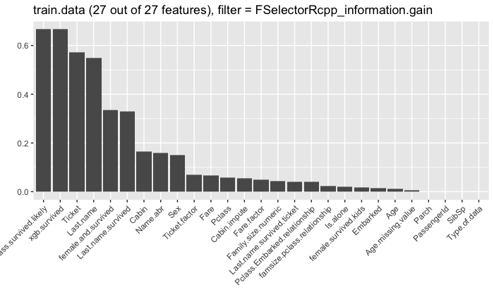

Modelling

```r
getParamSet("classif.randomForest")
```

|  | Type | len | Def | Constr | Req | Tunable | Trafo |
| --- | --- | --- | --- | --- | --- | --- | --- |
| ntree | integer | - | 500 | 1 to Inf | - | TRUE | - |
| mtry | integer | - | - | 1 to Inf | - | TRUE | - |
| replace | logical | - | TRUE | - | - | TRUE | - |
| classwt | numericvector | NA | - | 0 to Inf | - | TRUE | - |
| cutoff | numericvector | NA | - | 0 to 1 | - | TRUE | - |
| strata | untyped | - | - | - | - | FALSE | - |
| sampsize | integervector | NA | - | 1 to Inf | - | TRUE | - |
| nodesize | integer | - | 1 | 1 to Inf | - | TRUE | - |
| maxnodes | integer | - | - | 1 to Inf | - | TRUE | - |
| importance | logical | - | FALSE | - | - | TRUE | - |

[output cut: 7 more lines]

```
Provided data is not a pure data.frame but from class tbl_df, hence it will be converted.Resampling: repeated cross-validation
Measures:             mmce      acc
[Resample] iter 1:    0.0782123 0.9217877
[Resample] iter 2:    0.0674157 0.9325843
[Resample] iter 3:    0.0561798 0.9438202
[Resample] iter 4:    0.1011236 0.8988764
[Resample] iter 5:    0.0786517 0.9213483
[Resample] iter 6:    0.0617978 0.9382022
[Resample] iter 7:    0.0837989 0.9162011
[Resample] iter 8:    0.1061453 0.8938547
[Resample] iter 9:    0.0790960 0.9209040
[Resample] iter 10:   0.0898876 0.9101124
[Resample] iter 11:   0.0446927 0.9553073
[Resample] iter 12:   0.0674157 0.9325843
[Resample] iter 13:   0.0730337 0.9269663
[Resample] iter 14:   0.1292135 0.8707865
[Resample] iter 15:   0.0786517 0.9213483


Aggregated Result: mmce.test.mean=0.0796877,acc.test.mean=0.9203123


Provided data for prediction is not a pure data.frame but from class tbl_df, hence it will be converted.Provided data for prediction is not a pure data.frame but from class tbl_df, hence it will be converted.
```

Our tuned forest has an *CV* accuracy of ~0.92

```r
getParamSet("classif.xgboost")
```

|  | Type | len | Def | Constr | Req | Tunable | Trafo |
| --- | --- | --- | --- | --- | --- | --- | --- |
| booster | discrete | - | gbtree | gbtree,gblinear,dart | - | TRUE | - |
| watchlist | untyped | - |  | - | - | FALSE | - |
| eta | numeric | - | 0.3 | 0 to 1 | - | TRUE | - |
| gamma | numeric | - | 0 | 0 to Inf | - | TRUE | - |
| max_depth | integer | - | 6 | 0 to Inf | - | TRUE | - |
| min_child_weight | numeric | - | 1 | 0 to Inf | - | TRUE | - |
| subsample | numeric | - | 1 | 0 to 1 | - | TRUE | - |
| colsample_bytree | numeric | - | 1 | 0 to 1 | - | TRUE | - |
| colsample_bylevel | numeric | - | 1 | 0 to 1 | - | TRUE | - |
| num_parallel_tree | integer | - | 1 | 1 to Inf | - | TRUE | - |

[output cut: 34 more lines]

```
Provided data is not a pure data.frame but from class tbl_df, hence it will be converted.Resampling: repeated cross-validation
Measures:             mmce      acc
[Resample] iter 1:    0.0391061 0.9608939
[Resample] iter 2:    0.0280899 0.9719101
[Resample] iter 3:    0.0393258 0.9606742
[Resample] iter 4:    0.0561798 0.9438202
[Resample] iter 5:    0.0280899 0.9719101
[Resample] iter 6:    0.0280899 0.9719101
[Resample] iter 7:    0.0614525 0.9385475
[Resample] iter 8:    0.0446927 0.9553073
[Resample] iter 9:    0.0395480 0.9604520
[Resample] iter 10:   0.0337079 0.9662921
[Resample] iter 11:   0.0223464 0.9776536
[Resample] iter 12:   0.0280899 0.9719101
[Resample] iter 13:   0.0617978 0.9382022
[Resample] iter 14:   0.0617978 0.9382022
[Resample] iter 15:   0.0224719 0.9775281


Aggregated Result: mmce.test.mean=0.0396524,acc.test.mean=0.9603476


Provided data for prediction is not a pure data.frame but from class tbl_df, hence it will be converted.Provided data for prediction is not a pure data.frame but from class tbl_df, hence it will be converted.
```

Our tuned *XGB* has an *CV* accuracy of ~0.96

```r
getParamSet("classif.kknn")
```

|  | Type | len | Def | Constr | Req | Tunable | Trafo |
| --- | --- | --- | --- | --- | --- | --- | --- |
| k | integer | - | 7 | 1 to Inf | - | TRUE | - |
| distance | numeric | - | 2 | 0 to Inf | - | TRUE | - |
| kernel | discrete | - | optimal | rectangular,triangular,epanechnikov,b... | - | TRUE | - |
| scale | logical | - | TRUE | - | - | TRUE | - |

```
Provided data is not a pure data.frame but from class tbl_df, hence it will be converted.Resampling: repeated cross-validation
Measures:             mmce      acc
[Resample] iter 1:    0.0726257 0.9273743
[Resample] iter 2:    0.0674157 0.9325843
[Resample] iter 3:    0.0561798 0.9438202
[Resample] iter 4:    0.1011236 0.8988764
[Resample] iter 5:    0.0730337 0.9269663
[Resample] iter 6:    0.0617978 0.9382022
[Resample] iter 7:    0.0782123 0.9217877
[Resample] iter 8:    0.0837989 0.9162011
[Resample] iter 9:    0.0734463 0.9265537
[Resample] iter 10:   0.0898876 0.9101124
[Resample] iter 11:   0.0502793 0.9497207
[Resample] iter 12:   0.0505618 0.9494382
[Resample] iter 13:   0.0786517 0.9213483
[Resample] iter 14:   0.1235955 0.8764045
[Resample] iter 15:   0.0674157 0.9325843


Aggregated Result: mmce.test.mean=0.0752017,acc.test.mean=0.9247983


Provided data for prediction is not a pure data.frame but from class tbl_df, hence it will be converted.Provided data for prediction is not a pure data.frame but from class tbl_df, hence it will be converted.
```

Our tuned *KNN* has an *CV* accuracy of ~0.92

```r
getParamSet("classif.svm")
```

|  | Type | len | Def | Constr | Req | Tunable | Trafo |
| --- | --- | --- | --- | --- | --- | --- | --- |
| type | discrete | - | C-classifica... | C-classification,nu-classification | - | TRUE | - |
| cost | numeric | - | 1 | 0 to Inf | Y | TRUE | - |
| nu | numeric | - | 0.5 | -Inf to Inf | Y | TRUE | - |
| class.weights | numericvector | NA | - | 0 to Inf | - | TRUE | - |
| kernel | discrete | - | radial | linear,polynomial,radial,sigmoid | - | TRUE | - |
| degree | integer | - | 3 | 1 to Inf | Y | TRUE | - |
| coef0 | numeric | - | 0 | -Inf to Inf | Y | TRUE | - |
| gamma | numeric | - | - | 0 to Inf | Y | TRUE | - |
| cachesize | numeric | - | 40 | -Inf to Inf | - | TRUE | - |
| tolerance | numeric | - | 0.001 | 0 to Inf | - | TRUE | - |

[output cut: 4 more lines]

```
Provided data is not a pure data.frame but from class tbl_df, hence it will be converted.Resampling: repeated cross-validation
Measures:             mmce      acc
[Resample] iter 1:    0.0279330 0.9720670
[Resample] iter 2:    0.0224719 0.9775281
[Resample] iter 3:    0.0393258 0.9606742
[Resample] iter 4:    0.0449438 0.9550562
[Resample] iter 5:    0.0280899 0.9719101
[Resample] iter 6:    0.0224719 0.9775281
[Resample] iter 7:    0.0391061 0.9608939
[Resample] iter 8:    0.0614525 0.9385475
[Resample] iter 9:    0.0282486 0.9717514
[Resample] iter 10:   0.0449438 0.9550562
[Resample] iter 11:   0.0279330 0.9720670
[Resample] iter 12:   0.0337079 0.9662921
[Resample] iter 13:   0.0449438 0.9550562
[Resample] iter 14:   0.0617978 0.9382022
[Resample] iter 15:   0.0280899 0.9719101


Aggregated Result: mmce.test.mean=0.0370306,acc.test.mean=0.9629694


Provided data for prediction is not a pure data.frame but from class tbl_df, hence it will be converted.Provided data for prediction is not a pure data.frame but from class tbl_df, hence it will be converted.
```

Our tuned *SVM* has an *CV* accuracy of ~0.96

Ensemble methods: Stacking

Our *MEGA MODEL* would be *logistic regression*

```
Call:
glm(formula = y ~ ., family = binomial(link = "logit"), data = train.stack.data)

Deviance Residuals:
    Min       1Q   Median       3Q      Max
-2.7949  -0.2280  -0.2280   0.2017   2.7066

Coefficients:
            Estimate Std. Error z value Pr(>|z|)
(Intercept) -11.1593     0.6801 -16.407  < 2e-16 ***
rf            4.9576     1.2726   3.896 9.79e-05 ***
xgb          -0.1377     1.7189  -0.080  0.93614
knn          -4.7555     1.5487  -3.071  0.00214 **
svm           7.4579     1.8088   4.123 3.74e-05 ***
---
Signif. codes:  0 ‘***’ 0.001 ‘**’ 0.01 ‘*’ 0.05 ‘.’ 0.1 ‘ ’ 1

(Dispersion parameter for binomial family taken to be 1)

    Null deviance: 1186.66  on 890  degrees of freedom
Residual deviance:  202.78  on 886  degrees of freedom
AIC: 212.78

Number of Fisher Scoring iterations: 6

[1] 0.8014354
```

*Note:* Even though overfitting did occur in our training model (peduo-survival), we do see that using those values to create new features helped us imporve our final model performance

```r
dput(final.data.accuracy)
```

[output not shown]